# DRC M23 Conflict and Internally Displaced Population Analysis

Yeji Kim

2025-05-08

[output not shown]

### Yeji Kim (MIDP 25)

### Intro to Data Science 2025 Spring

# 1. Introduction

The Democratic Republic of Congo (DRC) faces one of the world’s largest and most complex internal displacement crises. As of early 2024, more than 6.9 million people were displaced within the country, with displacement concentrated in the eastern provinces of North Kivu, South Kivu, Ituri, and Tanganyika. Despite the DRC’s significant natural wealth, cycles of conflict, instability, and recurring shocks have continued to disrupt livelihoods and displace communities.

Understanding and anticipating patterns of internal displacement is critical for improving humanitarian response and long-term resilience efforts. While past research has explored the drivers of displacement in the DRC, there remains a need for predictive tools that can support early warning systems and anticipatory action.

This report aims for two goals: first, to descriptively understand the characteristics of the civil conflict and migration pattern; second, to use the characteristics of the most prolonged and urgen conflict M23 crisis and forcest the magnitude of international displacement at the submational level.

Drawing on monthly data between 2021 and 2025, the analysis explores the temporal and geographical relationship between conflict and migration and utilizes machine learning approaches to identify key predictors of the magnitude of displaced inviduals and assess how past/future conditions of conflict influence displacement trends. The findings are intended to support humanitarian actors, policymakers, and development partners in designing more proactive, data-driven interventions to protect vulnerable populations.

## 1-1. Research Question

### Descriptive Question:

What are the temporal and spatial characteristics of civil conflict and internal displacement in the Democratic Republic of Congo between 2021 and 2025, with a focus on the M23 crisis?

### Predictive Question:

To what extent can past and future conflict conditions predict the magnitude of internal displacement at the subnational (health zone) level using machine learning approaches?

# 2. Background: M23

M23, named after the March 23, 2009 agreement that ended a previous Tutsi‐led rebellion in eastern Congo, is the latest Tutsi‐led insurgency confronting the Congolese government (Reuters, 2025). The group re‐launched its rebellion in 2022, accusing the government of failing to implement the peace accord fully, particularly regarding the integration of Congolese Tutsis into the army and administrative structures (Reuters, 2025).

Between January and June 2024, the Internal Displacement Monitoring Centre (IDMC) recorded 2,012,000 internal displacements attributable to M23, making it the second‐largest conflict‐related displacement crisis globally for that period (IDMC, 2025). As of March 18, 2025, the M23 rebels have declined to join peace talks, indicating that the conflict and ensuing displacement are likely to persist (Al Jazeera, 2025).

Meanwhile, the Norwegian Refugee Council (NRC) has ranked the Democratic Republic of the Congo (DRC) among the world’s most overlooked displacement crises for eight consecutive years, with over 25 million people—about one‐quarter of the total population—facing violence, conflict, and disasters, and receiving only 41% of the required humanitarian funding (NRC, 2025).

Current research endeavors to shed light on conflict‐driven population movements, thereby guiding more effective humanitarian aid and shelter provision.

# 3. Data Preprocessing

## 3-1. Data Source

The data is collected from three different sources, each on Migration, Conflict, and Geography.

### IOM M23

First, the migration data is drawn from International Organization for Migration website, operated by UN Migration. Since the breakout of M23 crisis, IOM Displacement Tracking Matrix (DTM) has collected in total 23 rounds of “Évaluation Rapide de Crise M23” (Rapid M23 Crisis Evaluation) displacement data. Each rounds of data, dating from November 2022 to July 2024, totalling 59,264 observations were collected.

### ACLED API

Second source is ACLED (Armed Conflict Location and Event Date) API. First the conflict data is filtered for Democratic Republic of Congo and filtered for 2021 and onwards (following the whole duration of M23 conflict) and filtered again to capture M23 conflict only using actor1 == “M23: March 23 Movement” command.

### DRC Admin 3 GPKG

Next, to create heatmap and calculate how much internally displaced individuals travel, gpkg file containing multipolygon of admin 3 (health zone) is downloaded from https://data.humdata.org/dataset/zones-de-sante-rdc.

## 3-2. Data Cleaning

### IOM M23

For data cleaning, two major challenges rose for IOM data . First challenge was related to incoherent data structure, including mixture of french and english names of administrative regions, To address this, the names of administrative levels were translated to English and typos and incoherences were manually recoded.

Second challenge was incoherent number of columns (in other words, the amount of information collected) for each rounds. For example, round 2 of M23-DTM data was collected upto admin 2 level and displaced households, individuals (men, women, and children). The information tend to grow more granular in geographic level (reaching admin 3 all the way down to chiefdom) and from round 8 started to encode the origins admin 3 levels of the displaced population.To examine the movement of the IDPs, where they come from and go to, data was considered from round 8.

Third challenge was level of observation. Each row was number of IDPs at the unit of observation, which as described in example, varied number of individuals for each admin 2 (territory) or in later rounds of data number of individuals for chiefdom A who escaped conflict from chiefdom B. The solution was to group the observation by year, month, admin 3 of origin, and primary admin 3 of destination (when there were multiple admin 3 destination coded, the first destination was selected).

## 3-3. Final Data Merge

### IOM: M23_gis

After cleaning and summarizing for unique match of origin-destination of each year/month at admin 3 (healthzone) level, the data was joined with gpkg file to have geographic information column for origin and destination.

Then the centroid was calculated for the geom_des column and geom_og column and using ‘st_distance’ function, the distance travelled per each observation was coded as ‘dist’ column. The calculation was done in meters.

### ACLED: M23_acled_sf, DRC_acled_sf

Now for ACLED data, the variables of interest are the time of conflict, fatalities, civilian_targeting (a binary variable capturing whether the conflict was targeting civilian or not, 1 = yes, 0 = no), event type, and geographic information (admin 1 to 3 as well as longtitude and latitude).

First, as IOM data is coded monthly, and not daily, we also collapse the frequency of the number of conflict, fatalities, and for civilian_targeting we calculate the average of the civilian_targeting value of the given month (indicating what was the proportion of the conflict in given month was civilian targeted conflict).

** As for event type, since it was categorical variable containing multiple event types, for descriptive analysis, the dataset before collapsing into monthly level was utilized.

Second, after ACLED data is summarized into M23_acled, using the longtitude and latitude column, we assign admin 3 of the gpkg file. The reason for not matching admin 3 of M23_acled directly with gpkg file is due to the typos and language mismatch. The final conflict data frame, M23_acled_sf, containing polygon is created.

Third, to compare the M23 occurances with the whole conflict occurances in the most conflict-prone provinces, North-Kivu, South-Kivu and Ituri, same method is used to create dataframe, DRC_acled_sf that captures the total conflict in DRC.

### M23_final: IOM + ACLED

With migration data and conflict data collapsed to monthly level of admin 3, now final dataset can be created. Since the research aims to explore how M23 conflict of health zone A will impact residents of A to move out, when we are merging conflict and migration, we merge the two dataframe by origin of admin 3 from the migration data and admin 3 of the conflict data.

Also, the research would like to see if the conflict happened before or after will impact the internal movement. In other words, do individuals move before the conflict happens preemptively or as consequence of conflict? Hence, the conflict and conflict characteristics (fatalities, and civilian target) was lagged monthly for six months and lead monthly for six months, in total incorporating a whole year.

The final dataframe, M23_final_laglead, had 1650 observations, 59 variables.

[output not shown]

```
##  [1] "site_type"      "year"           "month"          "admin1"
##  [5] "admin2"         "admin3"         "household"      "individuals"
##  [9] "men"            "women"          "children"       "admin1_origine"
## [13] "admin2_origine" "admin3_origine"
```

[output not shown]

```
## Rows: 58,837
## Columns: 16
## Groups: year, month, admin2, admin3, admin2_origine_single, admin3_origine_single [2,061]
## $ site_type             <dbl+lbl> 0, 0, 0, 0, 0, 0, 0, 0, 0, 0, 0, 0, 0, 0, 0,…
## $ year                  <dbl> 2023, 2023, 2023, 2023, 2023, 2023, 2023, 2023, …
## $ month                 <dbl> 3, 3, 3, 3, 3, 3, 3, 3, 3, 3, 3, 3, 3, 3, 3, 3, …
## $ admin1                <chr> "North-Kivu", "North-Kivu", "North-Kivu", "North…
## $ admin2                <chr> "Nyiragongo", "Nyiragongo", "Lubero", "Lubero", …
## $ admin3                <chr> "Nyiragongo", "Nyiragongo", "Kayna", "Lubero", "…
## $ household             <dbl> 201, 234, 32, 134, 1138, 2250, 928, 400, 2573, 2…
## $ individuals           <dbl> 1272, 1506, 190, 682, 4946, 10017, 4229, 1866, 1…
## $ men                   <dbl> 458, 543, 72, 257, 1866, 3780, 1596, 704, 4632, …
## $ women                 <dbl> 688, 814, 107, 386, 2800, 5670, 2394, 1056, 6947…
## $ children              <dbl> 126, 149, 11, 39, 280, 567, 239, 106, 695, 750, …
## $ admin1_origine        <chr> "", "", "", "", "", "", "", "", "", "", "", "", …
## $ admin2_origine        <chr> NA, NA, NA, NA, NA, NA, NA, NA, NA, NA, NA, NA, …
## $ admin3_origine        <chr> NA, NA, NA, NA, NA, NA, NA, NA, NA, NA, NA, NA, …
## $ admin2_origine_single <chr> NA, NA, NA, NA, NA, NA, NA, NA, NA, NA, NA, NA, …
## $ admin3_origine_single <chr> NA, NA, NA, NA, NA, NA, NA, NA, NA, NA, NA, NA, …
```

```
## Success! Credentials authorized
```

```
## acled_access is TRUE, but email and key are included in the function. Ignoring acled_access.
```

```
## Requesting data for 1 country from 2021-03-01 to 2025-05-08
```

```
## This request requires 1 API calls. Do you want to proceed with this request?
## If you need to increase your API quota, please contact access@acleddata.com
```

```
## Processing API request
```

```
## Extracting content from API request
```

```
##  [1] "Alimbongo"    "Bambo"        "Beni"         "Biena"        "Binza"
##  [6] "Birambizo"    "Bunyakiri"    "Butembo"      "Goma"         "Itebero"
## [11] "Kalehe"       "Kalonge"      "Kalunguta"    "Kamango"      "Karisimbi"
## [16] "Katoyi"       "Katwa"        "Kayna"        "Kibirizi"     "Kibua"
## [21] "Kirotshe"     "Kyondo"       "Lubero"       "Mabalako"     "Manguredjipa"
## [26] "Masereka"     "Masisi"       "Minova"       "Musienene"    "Mutwanga"
## [31] "Mweso"        "Nyanzale"     "Nyiragongo"   "Oicha"        "Pinga"
## [36] "Rutshuru"     "Rwanguba"     "Vuhovi"       "Walikale"
```

```
##  [1] "Alimbongo"    "Bamb0"        "Bambo"        "Beni (Ville)" "Biena"
##  [6] "Binza"        "Birambizo"    "Goma"         "Itebero"      "Kalunguta"
## [11] "Kamango"      "Karisimbi"    "Katoyi"       "Katoyo"       "Katwa"
## [16] "Kayna"        "Kibirizi"     "Kibua"        "Kirotshe"     "Kyondo"
## [21] "Lubero"       "Mabalako"     "Manguredjipa" "Masereka"     "Masisi"
## [26] "Minova"       "Musienene"    "Mutwanga"     "Mweso"        "Nyiragongo"
## [31] "Oicha"        "Pinga"        "Rutshuru"     "Rwanguba"     "Vuhovi"
## [36] "Walikale"
```

```
##  [1]  1 NA  2 NA  4  5  6  9 10 13 14 15 16 NA 17 18 19 20 21 22 23 24 25 26 27
## [26] 28 29 30 31 33 34 35 36 37 38 39
```

```
##  [1]  1  2  3  4  5  6  9 10 13 14 15 16 NA 17 18 19 20 21 22 23 24 25 26 27 28
## [26] 29 30 31 32 33 34 35 36 37 38
```

```
##  [1]   6  19  36  38  43  47 121 140 171 174 196 208  NA 210 212 217 219 247 269
## [20] 295 317 333 337 341 356 387 391 398 424 429 443 452 455 491 492
```

```
##  [1]   6  19  36  38  43  47  86  90 121 140 162 170 171 174 196 208 210 212 217
## [20] 219 247 269 295 317 333 337 341 356 387 391 398 424 429 443 452 455 491 492
```

[output not shown]

[output not shown]

```
## Rows: 520
## Columns: 8
## $ full_id      <chr> "r10750251", "r10750642", "r10750349", "r10750161", "r107…
## $ attribution  <chr> "Référentiel Géographique Commun (RGC.cd)", "Référentiel …
## $ boundary     <chr> "health", "health", "health", "health", "health", "health…
## $ health_level <chr> "6", "6", "6", "6", "6", "6", "6", "6", "6", "6", "6", "6…
## $ name         <chr> "Biringi", "Kambala", "Aungba", "Kirotshe", "Aru", "Kizu"…
## $ ref.dhis2    <chr> "yS0pmMtanuT", "SkEKQLSulmp", "DFcltLEKLxj", "xS36Jly2x2T…
## $ alt_name     <chr> "", "", "", "", "", "", "", "", "", "", "", "", "", "", "…
## $ geom         <MULTIPOLYGON [°]> MULTIPOLYGON (((30.20772 2...., MULTIPOLYGON…
```

```
##    Min. 1st Qu.  Median    Mean 3rd Qu.    Max.    NA's
##   1.000   1.000   2.000   5.179   6.000  52.000     471
```

```
## [1] 0.1474565 0.2704443 0.3650998 0.4500966 0.5183516 0.5795235
```

```
## [1] 0.1474565 0.2704443 0.3650998 0.4500966 0.5183516 0.5795235
```

# 4. Descriptive Analysis

## 4-1. Internally Displaced Population (Migration Pattern)

### Figure 4.1 IOM Movement Origin Heatmap

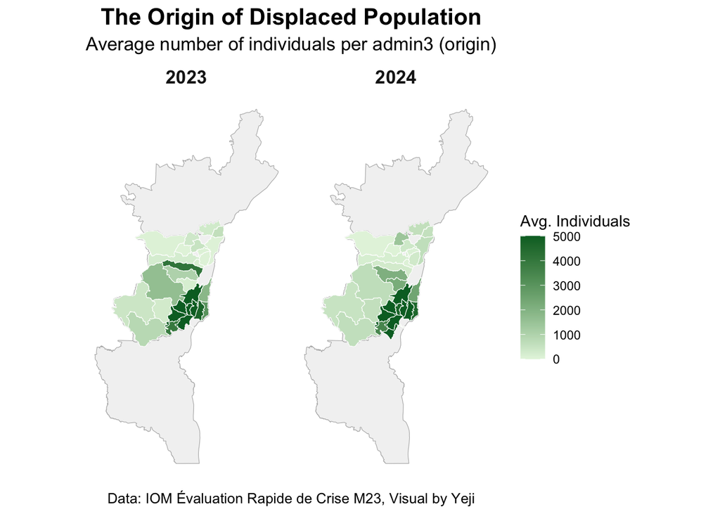

```r
# Step 1: Calculate average individuals per origin *per year*
M23_gis_og_avg <- M23_gis %>%
  group_by(year, admin3_origin_single, geom_og) %>%
  summarise(avg_individuals = mean(individuals, na.rm = TRUE)) %>%
  ungroup()
# Step 1: Calculate average individuals per origin *per year*
M23_gis_og_avg <- M23_gis %>%
  group_by(year, admin3_origin_single, geom_og) %>%
  summarise(avg_individuals = mean(individuals, na.rm = TRUE)) %>%
  ungroup()
# Step 2: Plot with facet by year (Green color scheme)
ggplot() +
  geom_sf(data = drc_admin1_filtered,
          fill = "gray95", color = "gray70", size = 0.3) +
  geom_sf(data = M23_gis_og_avg,
          aes(geometry = geom_og, fill = pmin(avg_individuals, 5000)),
          color = "white", size = 0.2) +

  scale_fill_gradient(
    name = "Avg. Individuals",
    low = "#e5f5e0",    # very light green
    high = "#006d2c",   # dark green
    na.value = "grey90",
    limits = c(0, 5000)
  ) +
  labs(
    title = "The Origin of Displaced Population",
    subtitle = "Average number of individuals per admin3 (origin)",
    fill = "Individuals",
    caption = "Data: IOM Évaluation Rapide de Crise M23, Visual by Yeji"
  ) +
  facet_wrap(~ factor(year, levels = c(2023, 2024))) +
  theme_minimal() +
  theme(
    axis.text = element_blank(),
    axis.ticks = element_blank(),
    panel.grid = element_blank(),
    plot.title = element_text(size = 16, face = "bold", hjust = 0.5),
    plot.subtitle = element_text(size = 13, hjust = 0.5),
    plot.caption = element_text(size = 10, hjust = 0.5),
    strip.text = element_text(size = 13, face = "bold"),
    legend.position = "right"
  )
```

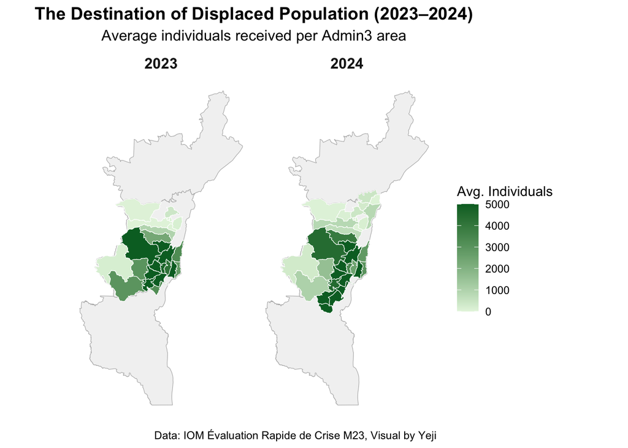

```r
### Figure 4.2. IOM Movement Destination Heatmap
library(ggplot2)
library(dplyr)
library(sf)

# Step 1: Aggregate average individuals per admin3 (destination)
M23_gis_dest_avg <- M23_gis %>%
  group_by(year, admin3, geom_des) %>%
  summarise(avg_individuals = mean(individuals, na.rm = TRUE)) %>%
  ungroup()
# Step 2: Plot (with green color scale)
ggplot() +
   geom_sf(data = drc_admin1_filtered,
          fill = "gray95", color = "gray70", size = 0.3) +
  geom_sf(data = M23_gis_dest_avg,
          aes(geometry = geom_des, fill = pmin(avg_individuals, 5000)),
          color = "white", size = 0.2) +

  # Green color scale
  scale_fill_gradient(
    name = "Avg. Individuals",
    low = "#e5f5e0",   # very light green
    high = "#006d2c",  # dark forest green
    na.value = "grey90",
    limits = c(0, 5000)
  ) +

  labs(
    title = "The Destination of Displaced Population (2023–2024)",
    subtitle = "Average individuals received per Admin3 area",
    caption = "Data: IOM Évaluation Rapide de Crise M23, Visual by Yeji",
    fill = "Individuals"
  ) +
  facet_wrap(~ factor(year, levels = c(2023, 2024))) +   # Separate maps for 2023 and 2024
  theme_minimal() +
  theme(
    axis.text = element_blank(),
    axis.ticks = element_blank(),
    panel.grid = element_blank(),
    plot.title = element_text(size = 14, face = "bold", hjust = 0.5),
    plot.subtitle = element_text(size = 12, hjust = 0.5),
    legend.position = "right",
    strip.text = element_text(size = 12, face = "bold")
  )
```

Two types of heat maps illustrate displacement patterns: the origin heatmap (Figure 4.1) and the destination heatmap (Figure 4.2). These visualizations, based on IOM Rapid Conflict Response data, depict the monthly average movement of IDPs at the admin 3 (health zone) level. The origin heatmap shows heavy out-migration from conflict-prone areas along the Rwanda–DRC border, particularly the southern part of North Kivu. Mweso (14,029 monthly displacement), Kibirizi (7,471), and Kirotshe (7,314) were top three highest displacement origin.

The destination heatmap reveals that displaced populations moved progressively farther inland, away from immediate conflict zones, seeking relative safety in less affected regions such as Minova (33,048), Kalehe (31,124) and Kibirizi (16,415). We find that the displacement disperses to a vicinity province, and shown in particular example of Kibirizi, sometimes people escape conflict from a origin to another conflict-prone healthzone, and in the end, having to fled secondly to vincinity zone. This suggests that displacement is not a single movement, but could be prolonged movement dispersed by months of pause.

### Figure 4.3. Displacement Flow

```
## Links is a tbl_df. Converting to a plain data frame.
```

[interactive chart not shown]

Figure 4.3 integrates information from the two heatmaps and visualizes the top ten displacement movements, measured as average monthly flows at the admin 3 (health zone) level, from conflict-affected origin zones to destination zones. Zones coded in green represent North Kivu, while those in orange indicate South Kivu province.

Consistent with previous findings, key origin zones include Mweso, Kirotshe, and Kibirizi, while major destination zones include Kalehe, Minova (both in South Kivu), and Kayna. This migration pattern highlights how escalating violence in health zones of North Kivu triggered large-scale and fragmented internal movement which is often toward neighboring provinces, but in some cases, such as Kibirizi, within the same conflict-affected zone.

### Figure 4.4. Average Travel Distance

```
##    Min. 1st Qu.  Median    Mean 3rd Qu.    Max.
##   20938   21892   26230   28538   28725   56416
```

[figure not shown]

### Figure 4.5. Displaced Population Demographics

```
##       year          month             men             women
##  Min.   :2023   Min.   : 1.000   Min.   : 906.9   Min.   :1114
##  1st Qu.:2023   1st Qu.: 3.000   1st Qu.:1523.4   1st Qu.:2285
##  Median :2024   Median : 5.000   Median :1807.3   Median :2365
##  Mean   :2024   Mean   : 6.111   Mean   :1983.1   Mean   :2585
##  3rd Qu.:2024   3rd Qu.:10.000   3rd Qu.:2203.1   3rd Qu.:2553
##  Max.   :2024   Max.   :12.000   Max.   :3903.2   Max.   :5305
##     children               geom_og
##  Min.   : 397.1   MULTIPOLYGON :9
##  1st Qu.: 558.3   epsg:4326    :0
##  Median : 603.3   +proj=long...:0
##  Mean   : 787.5
##  3rd Qu.:1092.8
##  Max.   :1477.8
```

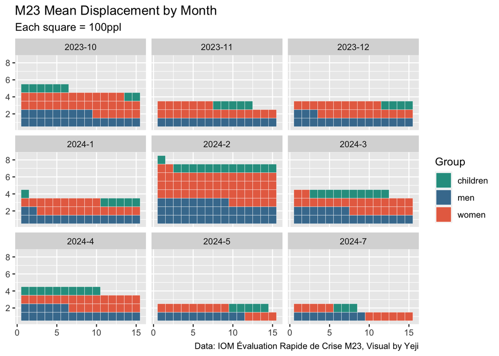

## 4-2. Internal Conflict

To contextualize the displacement patterns described above, this section analyzes the underlying conflict dynamics over the same period. While forced migration is shaped by multiple factors, conflict remains the most immediate and recurrent trigger for displacement across the DRC. Drawing on ACLED data, the following visualizations examine the frequency, geography, and typology of conflict events from 2021 to 2025. By mapping trends in both intensity and spatial distribution.

### Figure 4.6. Evolution of Conflict Events by Type

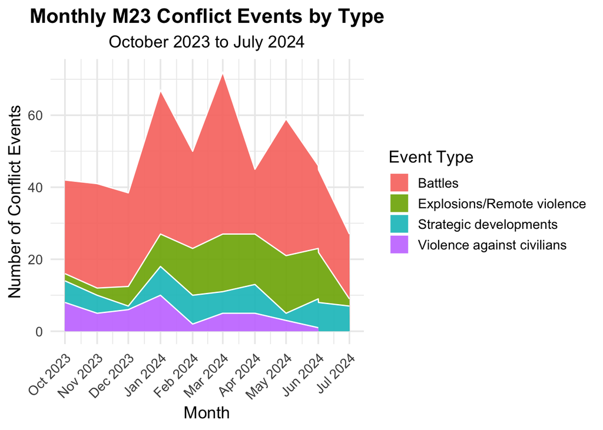

### Figure 4.7. M23 proportion

[figure not shown]

Since we are interested in North Kivu, let’s map the yearly distribution of number of M23 conflicts.

### Figure 4.8. yearly summary of conflicts in NK

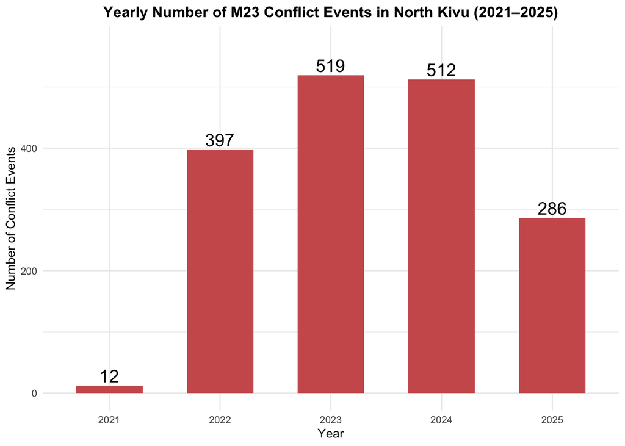

### Figure 4.9 Conflict Hotspots by Territory

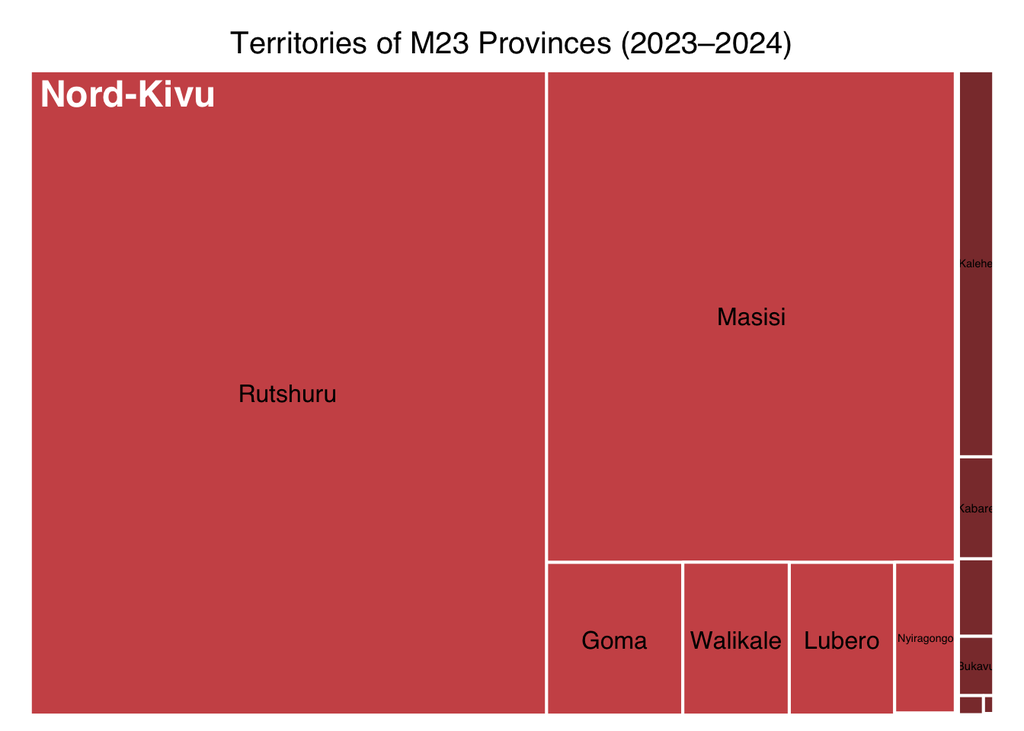

Figure 4.9. Territorial Concentration of M23 Conflict Events (2023–2024) This treemap illustrates the territorial concentration of M23-related conflict events at the administrative level 2 (territory level). The conflict was highly localized, with a disproportionately large number of events occurring in a few key territories—most notably Rutshuru and Masisi in North Kivu. Other territories such as Goma, Walikale, and Lubero also experienced notable levels of violence, while areas in South and Ituri provinces appear marginal. The visualization highlights that conflict intensity was not evenly distributed across the region, but rather concentrated in specific high-risk zones.

### Figure 4.10. admin 3 changes for M23 (2023, 2024)

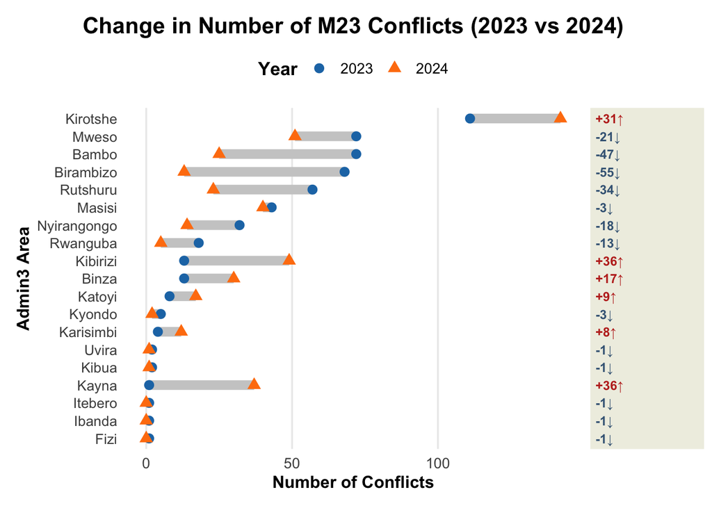

### Figure 4.11 connection between drc and M23

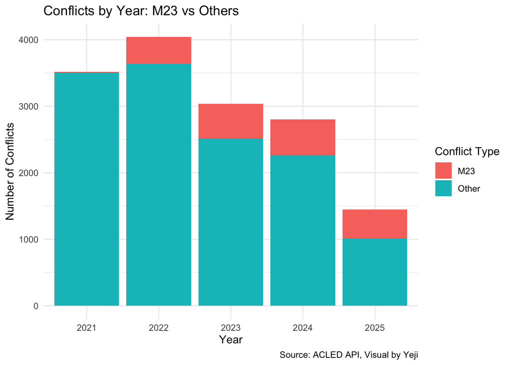

Figure 4.11. Yearly Comparison of M23 vs. Other Conflicts (2021–2025) This figure compares the annual number of conflict events attributed to the M23 group versus all other actors in the DRC from 2021 to 2025. While overall conflict levels have gradually declined since their 2022 peak, M23-related activity has taken up a larger share of total conflicts in recent years. Notably, in 2023 and 2024, M23 violence comprised a visible portion of total conflict, suggesting a growing role in the broader security landscape. By 2025, total conflict volumes dropped significantly, yet M23 incidents remained proportionally high, highlighting their sustained operational presence even amid broader de-escalation.